# Signs & Gestures (study2children)

## Remove Low-Looking Participants & Trials

Trials with less than 25% total looking duration are removed from our analysis. That means children that had 4 or more trials with <25% looking are dropped wholly from our analysis. These are the children we are dropping, below:

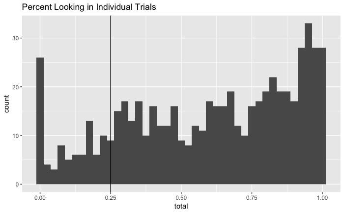

```r
# Count low trials
lowlooking <- data %>%
  group_by(name, signer, quality, age, media) %>%
  summarise(total = sum(percent, na.rm = TRUE))
# Plot
ggplot(lowlooking, aes(x = total)) + geom_histogram(binwidth = 0.025) +
  geom_vline(xintercept = .25) +
  ggtitle("Percent Looking in Individual Trials")
```

```r
# Get low-looking kids
lowlooking_kids <- lowlooking %>%
  mutate(low = total < .25) %>%
  group_by(name, signer, quality, age) %>%
  summarise(low_trials = sum(low)) %>%
  arrange(desc(low_trials)) %>%
  filter(low_trials > 3) %>%
  print(head(10))
```

| name | signer | quality | age | low_trials |
| --- | --- | --- | --- | --- |
| Madeliene_NS_5m | Non-signer | GOOD | 5.300000 | 7 |
| Adelaide NS 5m | Non-signer | needs correction | 5.600000 | 6 |
| James | Non-signer | GOOD | 6.466667 | 6 |
| Tavlina_3y | Signer | GOOD | 43.300000 | 6 |
| ha01to31_6m | Non-signer | GOOD | 5.966667 | 5 |
| Peyton_NSE_3y | Non-signer | GOOD | 36.000000 | 5 |
| Stella_SE | Signer | GOOD | 10.000000 | 5 |
| Jonah 6M NS | Non-signer | GOOD | 6.733333 | 4 |
| Kolby_6m_NS | Non-signer | Needs correction | 6.433333 | 4 |

On top of that, we’re also removing any <25% trials from our remaining (retained) kids so several of them will have less than 8 trials. Here they are, below.

```r
# Pull out lowlooking kids' names and use that to remove from main dataset via an anti_join
lowlooking_kids <- lowlooking_kids %>% select(name)
data <- data %>% anti_join(lowlooking_kids, by = "name")
# Now pull out low looking trials
lowlooking <- lowlooking %>%
  mutate(low = total < .25) %>%
  filter(low)
# Remove low looking trials from dataset
data <- data %>% anti_join(lowlooking, by = c("name","media"))
# Offer up how many kids have less than 8 trials.
data %>% select(name, media) %>%
  distinct() %>%
  count(name) %>%
  rename(valid_trials = n) %>%
  filter(valid_trials < 8) %>%
  arrange(desc(valid_trials))
```

| name | valid_trials |
| --- | --- |
| Alice_NS_5.5m | 7 |
| Avalon_10m_NS | 7 |
| Caleb_NS_6m | 7 |
| Catherine_NS_3y | 7 |
| Christopher_NS_5m | 7 |
| Clayton | 7 |
| Dakota SE 14m | 7 |
| el09se02_10m | 7 |
| Fabiana NS 2y | 7 |
| Gabrial_6m_NS | 7 |

[output cut: 19 more lines]

## Identify Outliers

Next we’ll identify any outliers/kids that need to be shifted. We’ll look at belly, belowchest, left, and right AOIs across all stories. Also, leftfacetop, midfacetop, and rightfacetop. Those AOIs traditionally have really low values, so consistently high values in these are indicators that the participant’s calibration is shifted. Kids with a lot of outlier values probably need to be shifted.

```r
# Make outlier list
outliers <- data %>% filter(aoi %in% c("belly","belowchest","left","right","leftfacetop",
                                       "midfacetop","rightfacetop")) %>%
  select(name, aoi, quality, media, aoi, percent) %>%
  arrange(aoi, desc(percent)) %>%
  group_by(aoi) %>%
  slice(1:20) %>%
  ungroup() %>%
  count(name) %>%
  arrange(desc(n))
outliers <- data %>%
  select(name, quality, signer) %>%
  distinct() %>%
  right_join(outliers, by = "name") %>%
  print()
```

| name | quality | signer | n |
| --- | --- | --- | --- |
| Avalon_10m_NS | GOOD | Non-signer | 14 |
| Da02ke23 | needs correction | Non-signer | 14 |
| Rowan_6m | needs correction | Non-signer | 14 |
| Elli_10m_NS | needs correction | Non-signer | 9 |
| Noa NS 5m | Needs correction | Non-signer | 9 |
| Bessie_4y_NS | GOOD | Non-signer | 8 |
| Lyra_NS_10M | needs correction | Non-signer | 8 |
| Dylan_4y_Signer | needs correction | Signer | 7 |
| Christopher_NS_5m | needs correction | Non-signer | 5 |
| Clayton | needs correction | Non-signer | 5 |

[output cut: 26 more lines]

Anyone with more than 2 may need to be checked for shifts. We can run this code again after shifting has happened, to perhaps catch any new outliers.

** For now I’m going to remove Avalon, Da02Ke23, Rowan, Elli, Noa, Bessie, Dylan, and Lyra**

```r
# Remove those with more than 5 outliers
outliers <- outliers %>%
  filter(n > 5) %>%
  select(name)
data <- anti_join(data, outliers, by = "name")
write_csv(data, "study1cleaneddata.csv")
```

# Let’s Play

Alright, let’s play. Grab the boxplot again.

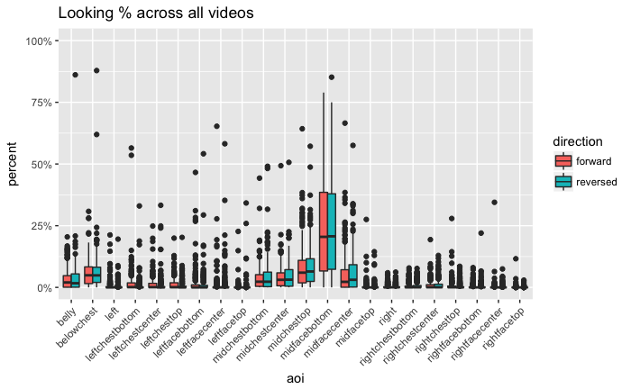

```r
ggplot(data, aes(x = aoi, y = percent, fill = direction)) +
  geom_boxplot() + theme(axis.text.x = element_text(angle=45, hjust = 1)) +
  ggtitle("Looking % across all videos") +
  scale_y_continuous(labels = scales::percent, limits = c(0,1))
```

As usual, most of the looking behavior is in the mid AOIs. We also seem to have several high values for belowchest AND belly, which is interesting (they’re also bigger AOIs too). Let’s look up close.

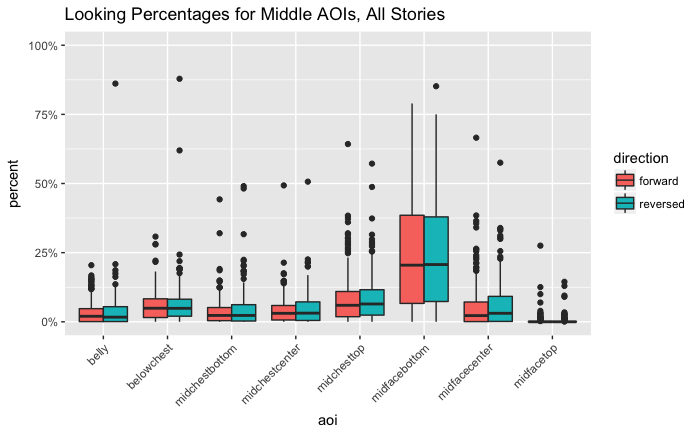

```r
data_mid <- data %>%
  filter(str_detect(aoi,"mid") | aoi == "belowchest" | aoi == "belly")
ggplot(data_mid, aes(x = aoi, y = percent, fill = direction)) +
  geom_boxplot() + theme(axis.text.x = element_text(angle=45, hjust = 1)) +
  ggtitle("Looking Percentages for Middle AOIs, All Stories") +
  scale_y_continuous(labels = scales::percent, limits = c(0,1))
```

We’ll just look at MidFaceBottom as that’s where the most is happening.

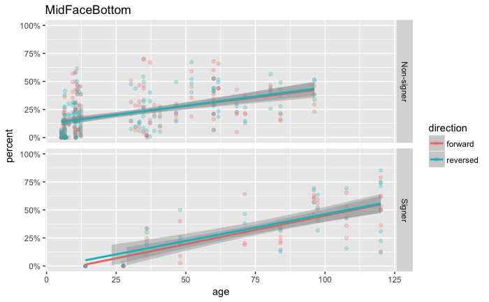

```r
data_mid %>%
  filter(aoi == "midfacebottom") %>%
  ggplot(aes(x = age, y = percent, color = direction)) + geom_point(alpha = 0.25) +
  geom_smooth(method = "lm") + facet_grid(signer ~ .) +
  scale_y_continuous(labels = scales::percent, limits = c(0,1)) +
  ggtitle("MidFaceBottom")
```

```r
# how many in each group?
kids <- data %>%
  select(name, signer, age) %>%
  distinct() %>%
  mutate(group = case_when(
    age <= 9 ~ "young_babies",
    age > 9 & age <= 18 ~ "older_babies",
    age > 18 ~ "children"
  )) %>%
  count(group, signer)
```